# Primer Notebook

[figure not shown]

```python
import pandas as pd
url = 'https://web.stanford.edu/class/archive/cs/cs109/cs109.1166/stuff/titanic.csv'
df = pd.read_csv(url)
print(df.head())
```

```
   Survived  Pclass                                               Name  \
0         0       3                             Mr. Owen Harris Braund
1         1       1  Mrs. John Bradley (Florence Briggs Thayer) Cum...
2         1       3                              Miss. Laina Heikkinen
3         1       1        Mrs. Jacques Heath (Lily May Peel) Futrelle
4         0       3                            Mr. William Henry Allen

      Sex   Age  Siblings/Spouses Aboard  Parents/Children Aboard     Fare
0    male  22.0                        1                        0   7.2500
1  female  38.0                        1                        0  71.2833
2  female  26.0                        0                        0   7.9250
3  female  35.0                        1                        0  53.1000
4    male  35.0                        0                        0   8.0500
```

```python
# Seleccionar columnas específicas
print(df.columns)

df_subset = df[['Survived', 'Sex', 'Age']]
print(df_subset.head())

# Filtrar datos
df_male = df[df['Sex'] == 'male']
print(df_male.head())

# Crear una nueva columna
df['FamilySize'] = df['Siblings/Spouses Aboard'] + df['Pclass'] + 1
print(df.head())
```

```
Index(['Survived', 'Pclass', 'Name', 'Sex', 'Age', 'Siblings/Spouses Aboard',
       'Parents/Children Aboard', 'Fare'],
      dtype='object')
   Survived     Sex   Age
0         0    male  22.0
1         1  female  38.0
2         1  female  26.0
3         1  female  35.0
4         0    male  35.0
   Survived  Pclass                           Name   Sex   Age  \
0         0       3         Mr. Owen Harris Braund  male  22.0
4         0       3        Mr. William Henry Allen  male  35.0
5         0       3                Mr. James Moran  male  27.0
6         0       1         Mr. Timothy J McCarthy  male  54.0
7         0       3  Master. Gosta Leonard Palsson  male   2.0
```

[output cut: 27 more lines]

Primero imprime el nombre de las columnas del conjunto de datos Crea un subconjunto de datos sólo con las 3 columnas Survived, sex y Age Crea otro subconjunto filtrando sólo los hombres a partir del conjunto original Imprime las primeras 5 filas del subconjunto de datos Finalmente crea una nueva columna en el conjunto original, el valor de esta columna, será la suma de las columnas Siblings/Spouses Aboard + Pclass + 1

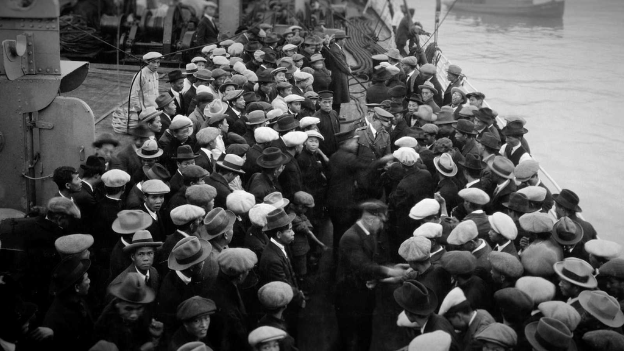

En la imagen se pueden visualizar algunos pasajeros del Titanic.

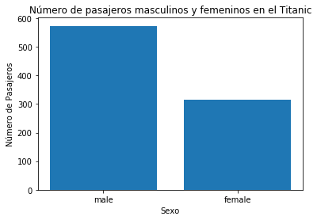

```python
import matplotlib.pyplot as plt
# Contar el número de pasajeros masculinos y femeninos
gender_counts = df['Sex'].value_counts()

# Crear un gráfico de barras
plt.bar(gender_counts.index, gender_counts.values)

# Agregar etiquetas y título
plt.xlabel('Sexo')
plt.ylabel('Número de Pasajeros')
plt.title('Número de pasajeros masculinos y femeninos en el Titanic')

# Mostrar el gráfico
plt.show()
```

El gráfico de barras que se generó representa el número de pasajeros masculinos y femeninos en el conjunto de datos del Titanic. En el eje x, se encuentran las dos categorías: "male" y "female", que representan los pasajeros hombres y mujeres, respectivamente. En el eje y, se encuentra el número de pasajeros correspondiente a cada categoría. El gráfico de barras es una forma efectiva de visualizar la distribución de una variable categórica (en este caso, el género) en un conjunto de datos. En este gráfico en particular, podemos observar que hay más pasajeros hombres que mujeres en el conjunto de datos del Titanic. Esto coincide con lo que sabemos de la historia del Titanic, donde había una mayor proporción de hombres a bordo del barco que de mujeres. El gráfico también tiene un título descriptivo y etiquetas claras para los ejes x e y, lo que facilita la interpretación de la información presentada en él

```python
import numpy as np

# Cálculo de la media de la edad de los pasajeros
mean_age = np.mean(df['Age'])
print("La media de edad de los pasajeros es: ", mean_age)

# Cálculo de la desviación estándar de la edad de los pasajeros
std_age = np.std(df['Age'])
print("La desviación estándar de la edad de los pasajeros es: ", std_age)

# Cálculo de la varianza de la edad de los pasajeros
var_age = np.var(df['Age'])
print("La varianza de la edad de los pasajeros es: ", var_age)
```

```
La media de edad de los pasajeros es:  29.471443066516347
La desviación estándar de la edad de los pasajeros es:  14.113945671023176
La varianza de la edad de los pasajeros es:  199.20346240459386
```

Utilizando los datos de conjunto original, se calculó la media, desviación estándar y varianza a la edad de los pasajeros.

La media se calcula sumando todos los valores y dividiendo el resultado en el recuento de los valores sumados.

La varianza se calcula así: Encuentra la diferencia de cada punto de datos con respecto al valor medio. Eleva al cuadrado cada uno de estos valores. Suma todos los valores elevados al cuadrado. Divide esta suma de cuadrados entre n – 1 (para una muestra) o N (para la población).

https://historia.nationalgeographic.com.es/a/vidas-truncadas-titanic_11387

Para mí es importante saber utilizar Jupyter Notebooks porque permite documentar código de una forma muy organizada para compartirlo con otras personas. Es importante conocer y saber utilizar las bibliotecas de Python porque facilitan realizar muchos procesos además de ahorrar tiempo de desarrollo al utilizar las funciones de las bibliotecas.